# Week 3 Skill Builders

Omegara Chidinma

2024-11-01

## Assignment

### Chapter 6 questions

6M1. Modify the DAG on page 186 to include the variable V, an unobserved cause of C and Y: C V Y. Reanalyze the DAG. How many paths connect X to Y? Which must be closed? Which variables should you condition on now?

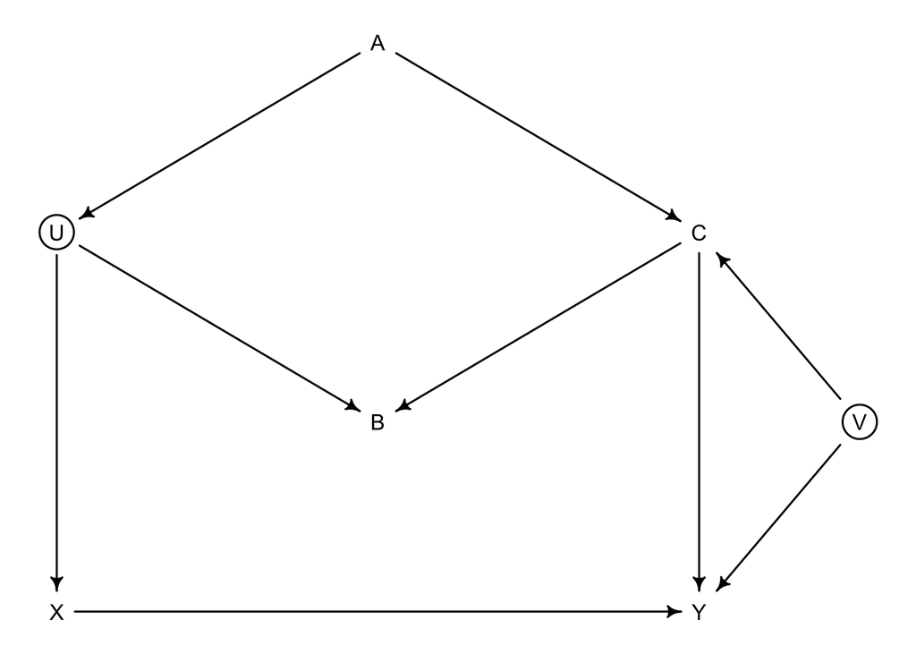

```r
library(dagitty)
dag_6M1 <- dagitty("dag{
U [unobserved]
V [unobserved]
X -> Y
X <- U -> B <- C -> Y
U <- A -> C
C <- V -> Y }")
coordinates(dag_6M1) <- list(
x=c(X=0,Y=2,U=0,A=1,B=1,C=2,V=2.5),
y=c(X=2,Y=2,U=1,A=0.5,B=1.5,C=1,V=1.5) )
drawdag(dag_6M1)
```

6M2. Sometimes, in order to avoid multicollinearity, people inspect pairwise correlations among predictors before including them in a model. This is a bad procedure, because what matters is the conditional association, not the association before the variables are included in the model. To highlight this, consider the DAG $X \rightarrow Z \rightarrow Y$. Simulate data from this DAG so that the correlation between X and Z is very large. Then include both in a model to predict $Y$. Do you observe any multicollinearity? Why or why not? What is different from the legs example in the chapter?

6M3. Learning to analyze DAGs requires practice. For each of the four DAGs below, state which variables, if any, you must adjust for (condition on) to estimate the total causal influence of $X$ on $Y$.

[figure not shown]

6H3. Use a model to infer the total causal influence of area on weight. Would increasing the area available to each fox make it heavier (healthier)? You might want to standardize the variables. Regardless, use prior predictive simulation to show that your model’s prior predictions stay within the possible outcome range.

6H4. Now infer the causal impact of adding food to a territory. Would this make foxes heavier? Which covariates do you need to adjust for to estimate the total causal influence of food?

6H5. Now infer the causal impact of group size. Which covariates do you need to adjust for? Looking at the posterior distribution of the resulting model, what do you think explains these data? That is, can you explain the estimates for all three problems? How do they go together?

### Chapter 7 questions

7H1. In 2007, The Wall Street Journal published an editorial (“We’re Number One, Alas”) with a graph of corporate tax rates in 29 countries plotted against tax revenue. A badly fit curve was drawn in, seemingly by hand, to make the argument that the relationship between tax rate and tax revenue increases and then declines, such that higher tax rates can actually produce less tax revenue. I want you to actually fit a curve to these data, found in `data(Laffer)`. Consider models that use tax rate to predict tax revenue. Compare, using WAIC or PSIS, a straight-line model to any curved models you like. What do you conclude about the relationship between tax rate and tax revenue?

7H2. Consider three fictional Polynesian islands. On each there is a Royal Ornithologist charged by the king with surveying the bird population. They have each found the following proportions of 5 important bird species:

```r
library(kableExtra)
dt <- mtcars[1:5, 1:4]
dt <- tibble(
  Island_1 = c( 0.2, 0.2, 0.2, 0.2, 0.2 ),
  Island_2 = c( 0.8, 0.1, 0.05, 0.025, 0.025 ),
  Island_3 = c( 0.05, 0.15, 0.7, 0.05, 0.05)
)
rownames(dt) <- c( "Species A", "Species B", "Species C", "Species D", "Species E" )
colnames(dt) <- c( "Island 1", "Island 2", "Island 3")
# HTML table
kbl(dt, caption = "Birds of a Feather") %>%
  kable_styling(bootstrap_options = "striped",
                full_width = F)
```

Birds of a Feather

| Island 1 | Island 2 | Island 3 |
| --- | --- | --- |
| 0.2 | 0.800 | 0.05 |
| 0.2 | 0.100 | 0.15 |
| 0.2 | 0.050 | 0.70 |
| 0.2 | 0.025 | 0.05 |
| 0.2 | 0.025 | 0.05 |

- What does each column add up to?

This problem has two parts. It is not computationally complicated. But it is conceptually tricky.

- First, compute the entropy of each island’s bird distribution. Interpret these entropy values.
- Second, use each island’s bird distribution to predict the other two. This means to compute the KL divergence of each island from the others, treating each island as if it were a statistical model of the other islands. You should end up with 6 different KL divergence values.

Which island predicts the others best? Why?

7H5. Revisit the urban fox data, data(foxes), from the previous chapter’s practice problems. Use WAIC or PSIS based model comparison on five different models, each using weight as the outcome, and containing these sets of predictor variables:

1. avgfood + groupsize + area
2. avgfood + groupsize
3. groupsize + area
4. avgfood
5. area

Can you explain the relative differences in WAIC scores, using the fox DAG from the previous chapter? Be sure to pay attention to the standard error of the score differences (dSE).

## Chapter 6 Solutions

### 6M1: How many roads can we walk down?

From p. 186 in the text, the DAG below contains an exposure of interest X, an outcome of interest Y, an unobserved variable U, and three observed covariates (A, B, and C) that are somehow involved with X and Y.

We are interested in the $X \rightarrow Y$ path, which depicts the causal effect of X on Y. Which of the observed covariates do we need to add to the model, in order to correctly infer it?

To figure this out, we look for backdoor paths. Aside from the direct path, there is first the causal path from X to Y. Also there are two other paths from X to Y:

$$\begin{align}
(1) X &\rightarrow Y, \,\,\,\, \text{(the causal path)} \\
(2) X &\leftarrow U \leftarrow A \rightarrow C \rightarrow Y \\
(3) X &\leftarrow U \rightarrow B \leftarrow C \rightarrow Y
\end{align}$$

Paths 2 and 3 are both backdoor paths that could confound inference. Thus we ask which of these paths is open. If a backdoor path is open, then we must close it. If a backdoor path is closed already, then we must not accidentally open it and create a confound. Either A or C will shut the backdoor. This the answer given by `adjustmentSets()`.

```r
library(dagitty)
dag_6.1 <- dagitty( "dag {
U [unobserved]
X -> Y
X <- U <- A -> C -> Y
U -> B <- C
}")
adjustmentSets( dag_6.1 , exposure="X" , outcome="Y" )
```

```
## { C }
## { A }
```

Conditioning on either C or A would suffice. Conditioning on C is the better idea, from the perspective of efficiency, since it could also help with the precision of the estimate of $X \rightarrow Y$. So much from the text.

Here is a DAG that includes the variable V, an unobserved cause of C and Y such that C V Y.

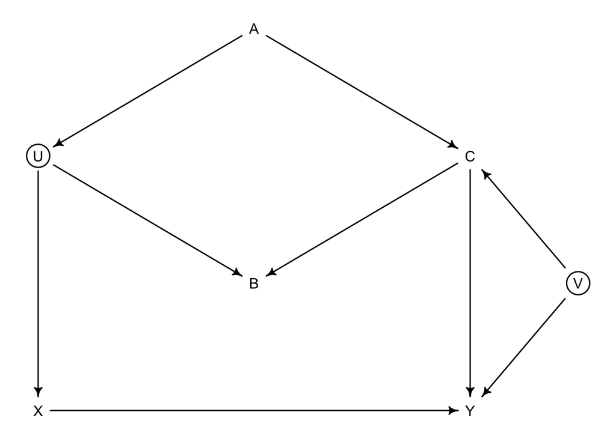

```r
library(dagitty)
dag_6M1 <- dagitty("dag{
  U [unobserved]
  V [unobserved]
  X -> Y
  X <- U -> B <- C -> Y
  U <- A -> C
  C <- V -> Y }")
coordinates(dag_6M1) <- list(
  x=c(X=0,Y=2,U=0,A=1,B=1,C=2,V=2.5),
  y=c(X=2,Y=2,U=1,A=0.5,B=1.5,C=1,V=1.5)
  )
drawdag(dag_6M1)
```

Now there are 5 paths connecting X and Y:

$$\begin{align}
(1) X &\rightarrow Y \text{(the causal path)} \\
(2) X &\leftarrow U \rightarrow B \leftarrow C \rightarrow Y \\
(3) X &\leftarrow U \rightarrow B \leftarrow C \leftarrow V
\rightarrow Y \\
(4) X &\leftarrow U \leftarrow A \rightarrow C \rightarrow Y \\
(5) X &\leftarrow U \leftarrow A \rightarrow C \leftarrow V
\rightarrow Y
\end{align}$$

We want to leave path 1 open and make sure all of the others are closed, because they are non-causal paths that will otherwise confound inference. As before, all the paths through B are already closed, since B is a collider (*Why?*). So we don’t condition on B.

In a similar way, the new paths through both A and V are closed, because C is a collider on those paths. So it will be enough to condition on A to close all non-causal paths.

Let’s can check this reasoning using `dagitty`:

```r
adjustmentSets( dag_6M1 , exposure="X" , outcome="Y" )
```

```
## { A }
```

A question (or two):

- Note that in the chapter, where V is absent, it is also fine to condition on C. That is no longer the case, again explain why. When V is introduced as an unobserved cause of both C and Y, conditioning on C alone is no longer enough because C becomes a collider for the paths that include V. This means that conditioning on C would open a path through V, allowing for potential confounding effects from V on Y. Instead, conditioning on A, which does not involve this new collider structure with V, effectively blocks all backdoor paths without unintentionally opening new ones. Thus, A remains the optimal adjustment set.
- What is the role of the collider? A collider is a node where two paths converge, like the structure around B or C in the DAG. When a collider is conditioned on, it opens a path between the variables that converge upon it, creating an association where there was none before. In this DAG, B and C act as colliders on certain paths, and conditioning on these colliders can inadvertently open non-causal paths between X and Y, introducing bias in the causal inference. Therefore, identifying colliders is critical for deciding which variables to avoid conditioning on. Another question (or two):
- What is a DAG good for? A DAG (Directed Acyclic Graph) is useful for visualizing causal relationships and dependencies between variables. It helps in identifying potential confounding paths and determining which variables to condition on to obtain an unbiased estimate of a causal effect. DAGs also reveal colliders, mediators, and potential backdoor paths, allowing researchers to develop models that capture the true causal mechanisms in complex systems.
- When don’t we need a DAG? We may not need a DAG when causal inference is not the primary goal, such as in simple predictive modeling where the focus is on forecasting rather than understanding causal relationships. Additionally, if we have strong prior knowledge of independence between predictors and the outcome, or if we are conducting purely exploratory analysis, a DAG may be less essential. However, in most cases where causation is of interest, a DAG can provide valuable insight into variable dependencies and the structure of causal paths.

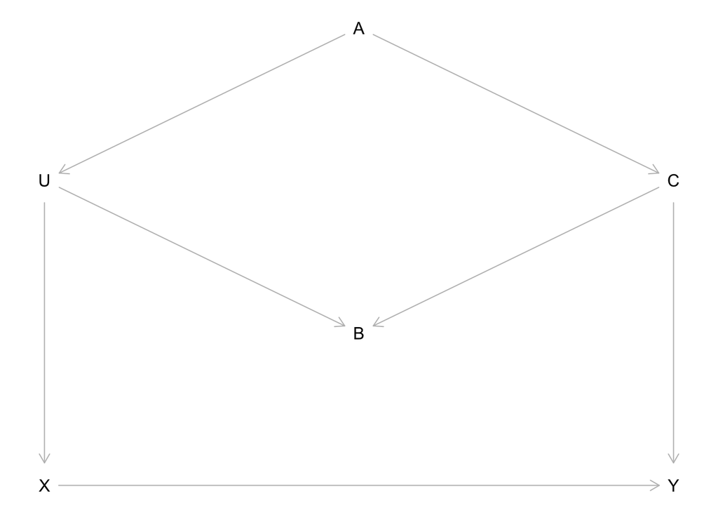

```r
library(dagitty)

dag_original <- dagitty("dag {
  U [unobserved]
  X -> Y
  X <- U <- A -> C -> Y
  U -> B <- C
}")
coordinates(dag_original) <- list(
  x=c(X=0,Y=2,U=0,A=1,B=1,C=2),
  y=c(X=2,Y=2,U=1,A=0.5,B=1.5,C=1)
)
plot(dag_original, main = "Original DAG (without V)")
```

```r
adjust_original <- adjustmentSets(dag_original, exposure="X", outcome="Y")
print(adjust_original)
```

```
## { C }
## { A }
```

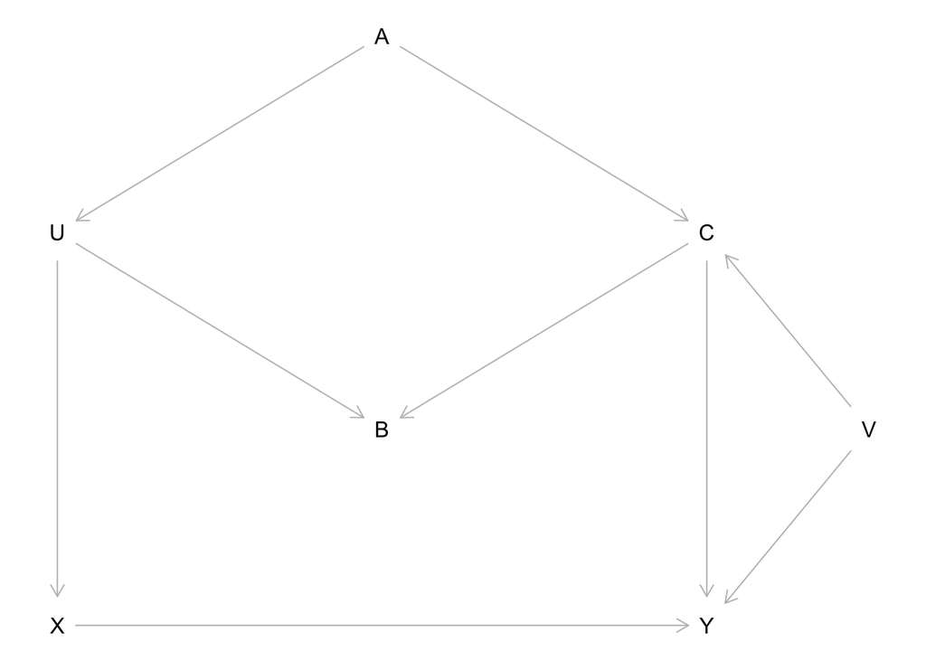

```r
dag_modified <- dagitty("dag {
  U [unobserved]
  V [unobserved]
  X -> Y
  X <- U -> B <- C -> Y
  U <- A -> C
  C <- V -> Y
}")
coordinates(dag_modified) <- list(
  x=c(X=0,Y=2,U=0,A=1,B=1,C=2,V=2.5),
  y=c(X=2,Y=2,U=1,A=0.5,B=1.5,C=1,V=1.5)
)
plot(dag_modified, main = "Modified DAG (with V)")
```

```r
adjust_modified <- adjustmentSets(dag_modified, exposure="X", outcome="Y")
print(adjust_modified)
```

```
## { A }
```

```r
cat("In the modified DAG, conditioning on C opens up paths through V, creating confounding.
Therefore, we only condition on A to block non-causal paths without introducing new biases.\n")
```

```
## In the modified DAG, conditioning on C opens up paths through V, creating confounding.
## Therefore, we only condition on A to block non-causal paths without introducing new biases.
```

```r
cat("DAGs are useful to visualize causal paths, identify confounders, and decide which variables
to condition on to ensure unbiased causal inference. When pure prediction is the focus, DAGs may
not be necessary.\n")
```

```
## DAGs are useful to visualize causal paths, identify confounders, and decide which variables
## to condition on to ensure unbiased causal inference. When pure prediction is the focus, DAGs may
## not be necessary.
```

### 6M2 – Rock ’em sock ’em

Mathematically, an example of multicollinearity effectively means we cannot solve a simultaneous equation. that is because the determinant of a coefficient matrix is zero. Here is perfectly correlated set of data. The two columns in this matrix are exactly the same. In general, one column is linearly dependent on another.

```r
A <- matrix( c(2, 3), nrow = 2, ncol = 2)
b <- matrix( c(4, 5), nrow =2, ncol = 1)
# solve Ax = b for x = inverse(A)b
inverse_A <- solve(A)
```

If you were to run this code, you would get back this error:

> Error in solve.default(A) : Lapack routine dgesv: system is exactly singular: U[2,2] = 0

This exactly correlated set of columns in A will not solve because it is singular. That means that we cannot distinguish between the two columns. It is as if there is only one column in A.

Now for a demonstration of noisy, that is, partially correlated data. To simulate collinear data:

```r
N <- 1000
X <- rnorm(N)
Z <- rnorm(N,X,0.1)
Y <- rnorm(N,Z)
cor(X,Z)
```

```
## [1] 0.995523
```

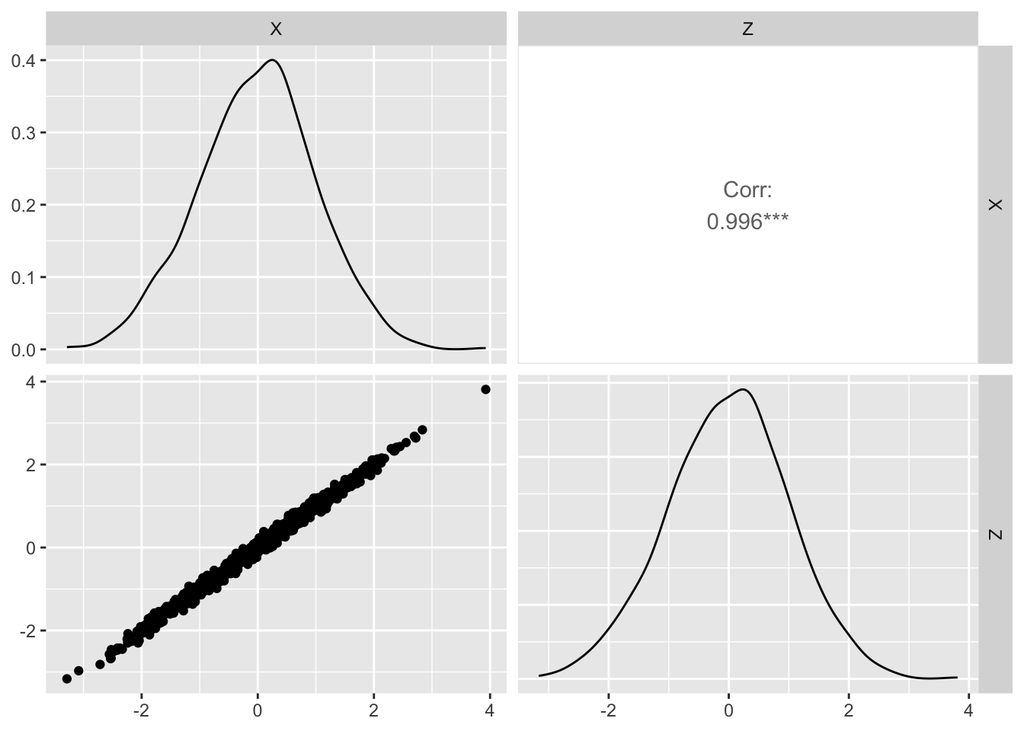

```r
XZ <- tibble( X = X, Z = Z)
XZ %>%
  ggpairs()
```

How correlated? Are X and Z the same variable or different variables? If the same why use both? X and Z are almost perfectly correlated. While X and Z are technically different variables, they are almost indistinguishable due to the way Z is generated as Z=X+ϵ (with a very small noise component, (ϵ). This high similarity means that including both in the model is nearly redundant. However, we include both to demonstrate how multicollinearity (the high correlation between predictors) affects the model’s estimation precision, even when the predictors are very similar.

Let’s regress:

```r
m_6M2 <- quap(
  alist(
    Y ~ dnorm( mu , sigma ),
    mu <- a + bX*X + bZ*Z,
    c(a,bX,bZ) ~ dnorm(0,1),
    sigma ~ dexp(1)
) , data=list(X=X,Y=Y,Z=Z) )
precis( m_6M2 )
```

```
##              mean         sd        5.5%      94.5%
## a     -0.01432052 0.03181112 -0.06516083 0.03651979
## bX    -0.04501667 0.30217338 -0.52794810 0.43791476
## bZ     1.07640757 0.30145616  0.59462240 1.55819274
## sigma  1.00623398 0.02248557  0.97029770 1.04217027
```

The standard deviations are larger than we might expect, for such a large sample. But the model has no trouble finding the truth here.

**Bottom line:** We must interpret multicollinearity both in the context of data, but more importantly in the construction of a model. We choose the data to put into the model. This pathological condition is not a property of the data alone. The model and the modeler have some culpability as well.

### 6M3 – Paths of least resistance?

In each case, the procedure is the same:

- List all paths between X and Y
- Identify open non-causal paths are open and
- Hunt for variables to close the open non-causal paths.

We’ll consider each of these panes in turn:

[figure not shown]

- *Top left.* There are three paths between X and Y:
1. X Y,
2. X Z Y,
3. X Z A Y.

Both (2) and (3) are open, non-causal paths. Conditioning on Z is sufficient to close both.

*Top right.* Again three paths:

$$\begin{align}
(1) X \rightarrow Y,
(2) X \leftarrow Z \rightarrow Y,
(3) X \leftarrow Z \leftarrow A \rightarrow Y.
\end{align}$$

Paths (1) and (2) are both causal. We want both open. Path (3) is non-causal, but it is also closed already because Z is a collider on that path.

*Bottom left.* Paths:

$$\begin{align}
(1) \,X &\rightarrow Y, \\
(2) \,X &\leftarrow Z \leftarrow Y, \\
(3) \,X &\leftarrow A \rightarrow Z \leftarrow Y.
\end{align}$$

Only path (1) is causal. The other paths are both closed, because both contain a collider at Z. Conditioning on Z would be a disaster. Bottom right. Paths:

$$\begin{align}
(1) \,X &\rightarrow Y, \\
(2) \,X &\leftarrow Z \leftarrow Y, \\
(3) \,X &\leftarrow A \rightarrow Z \rightarrow Y.
\end{align}$$
Paths (1) and (2) are causal. Path (3) is an open backdoor path. To close it, we must condition on A or Z, but if condition on Z, that would close a causal path.

### 6H3 – Weighty matters

Here is the DAG again.

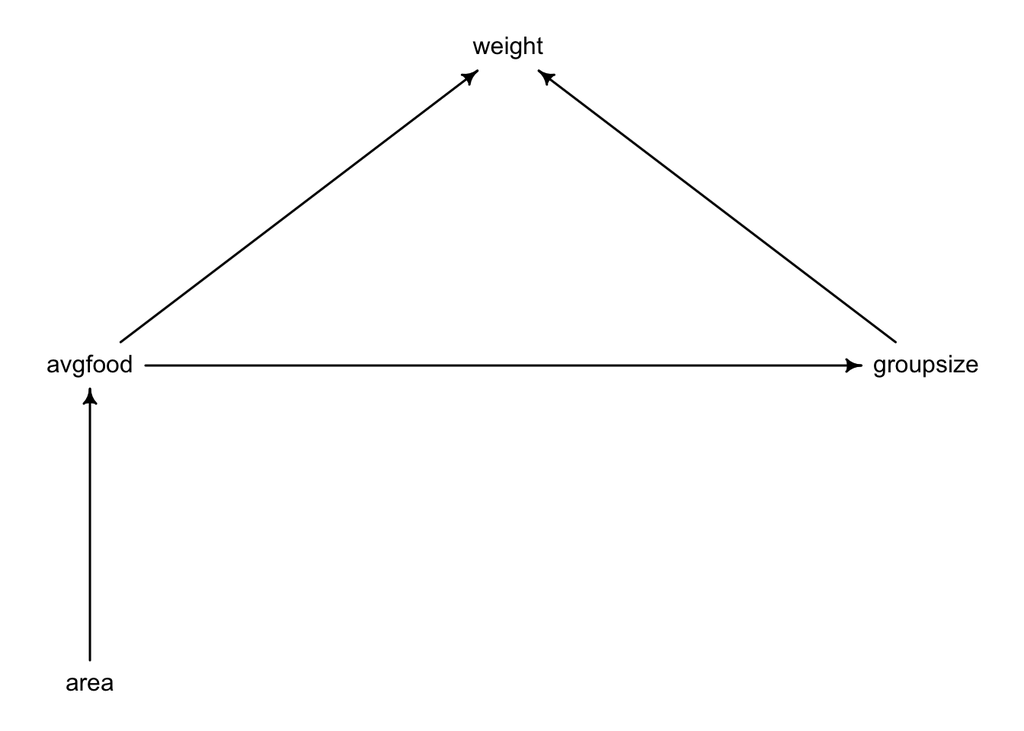

```r
library(dagitty)
dag_6H3 <- dagitty("dag{
  avgfood -> weight <- groupsize
  avgfood -> groupsize
  area -> avgfood
  }"
)
coordinates(dag_6H3) <- list(
  x=c(avgfood=0,groupsize=2,weight=1,area=0),
  y=c(avgfood=1,groupsize=1,weight=0,area=2)
  )
drawdag(dag_6H3)
```

Let’s start the interrogation.

- If there are no back-door paths from area to weight, what should we include?

Here is a model using standardized versions of the variables and those standardized priors from the book:

```r
library(rethinking)
data(foxes)
d <- foxes
d$W <- standardize(d$weight)
d$A <- standardize(d$area)
m1 <- quap(
alist(
W ~ dnorm( mu , sigma ),
mu <- a + bA*A,
a ~ dnorm(0,0.2),
bA ~ dnorm(0,0.5),
sigma ~ dexp(1)
), data=d )
precis(m1)
```

```
##                mean         sd       5.5%     94.5%
## a     -4.574278e-07 0.08360871 -0.1336233 0.1336224
## bA     1.883626e-02 0.09089587 -0.1264329 0.1641054
## sigma  9.912666e-01 0.06466657  0.8879169 1.0946163
```

Some followup questions, of course.

- What is the influence of territory size? The influence of territory size on fox weight appears to be very minimal based on the model results. The coefficient bA (representing the effect of standardized territory size) has a mean estimate of 0.0188 with a wide credible interval that includes zero (-0.126 to 0.164). This interval suggests that any effect of territory size on weight is likely weak and not statistically significant, as the credible interval implies that the effect could even be slightly negative. In summary, the model indicates that territory size (area) has little to no influence on fox weight, meaning that simply increasing territory size does not have a substantial impact on a fox’s weight or, by extension, its health.

### 6H4 - Free lunches for fox gangs?

To infer the causal influence of avgfood on weight, we need to close any back-door paths. There are no back-door paths in the DAG. So again, we can just use a model with a single predictor.

- What happens if we include groupsize, to block the indirect path? Including groupsize isolates the direct effect of avgfood on weight by blocking the indirect path. This may improve precision by accounting for variation in group size. However, it’s not necessary for causal inference as no backdoor paths exist from avgfood to weight.
- But how about the effect of adding food? Adding food has a minimal and uncertain effect on fox weight, with the model’s estimate close to zero and a wide credible interval. This suggests that food availability alone may not significantly impact weight. Other factors, like group competition or territory, could play a larger role.

```r
d$F <- standardize(d$avgfood)
m2 <- quap(
alist(
W ~ dnorm( mu , sigma ),
mu <- a + bF*F,
a ~ dnorm(0,0.2),
bF ~ dnorm(0,0.5),
sigma ~ dexp(1)
), data=d )
precis(m2)
```

```
##                mean         sd       5.5%     94.5%
## a     -3.893087e-07 0.08360015 -0.1336096 0.1336088
## bF    -2.421189e-02 0.09088499 -0.1694636 0.1210399
## sigma  9.911436e-01 0.06465853  0.8878068 1.0944805
```

More questions.

- What is the effect of adding food? The effect of adding food (avgfood) on fox weight is minimal and uncertain. The estimated coefficient for avgfood is close to zero with a wide credible interval, indicating that there’s no strong evidence that additional food significantly affects weight.
- Does this have anything to do with area? Yes, area indirectly influences weight by affecting avgfood. In the DAG, area increases avgfood availability, which could impact weight. However, in this model, area does not directly affect the causal inference about avgfood on weight.

### 6H5 – Back doors

The variable groupsize does have a back-door path, passing through avgfood. So to infer the causal influence of groupsize, we need to close that path. This implies a model with both groupsize and avgfood as predictors.

```r
d$G <- standardize(d$groupsize)
m3 <- quap(
alist(
  W ~ dnorm( mu , sigma ),
  mu <- a + bF*F + bG*G,
  a ~ dnorm(0,0.2),
  c(bF,bG) ~ dnorm(0,0.5),
  sigma ~ dexp(1)
), data=d )
precis(m3)
```

```
##                mean         sd       5.5%      94.5%
## a      1.623603e-06 0.08013821 -0.1280747  0.1280780
## bF     4.772706e-01 0.17912335  0.1909969  0.7635443
## bG    -5.735343e-01 0.17914195 -0.8598378 -0.2872309
## sigma  9.420460e-01 0.06175289  0.8433529  1.0407390
```

Some questions: